# Probability and Statistics

# Lab Assignment 1: Naive Bayes Classifier

## Work breakdown

- *Vitalii Sharaiev*: conditional probability function, predict, score.
- *Olga Havryliuk*: all additional function, predict.
- *Mariia Ivanchenko*: prepare data, vizualization, predict.

## Introduction

During the first three weeks, you learned a couple of essential notions and theorems, and one of the most important among them is the *Bayes theorem*.

One of its applications is **Naive Bayes classifier**, which is a probabilistic classifier whose aim is to determine which class some observation probably belongs to by using the Bayes formula:
$$\mathsf{P}(\mathrm{class}\mid
\mathrm{observation})=\frac{\mathsf{P}(\mathrm{observation}\mid\mathrm{class})\mathsf{P}(\mathrm{class})}{\mathsf{P}(\mathrm{observation})}$$

Under the strong independence assumption, one can calculate $\mathsf{P}(\mathrm{observation} \mid \mathrm{class})$ as
$$\mathsf{P}(\mathrm{observation}) =
\prod_{i=1}^{n} \mathsf{P}(\mathrm{feature}_i), \qquad
\mathsf{P}(\mathrm{observation} \mid \mathrm{class}) = \prod_{i=1}^{n}
\mathsf{P}(\mathrm{feature}_i \mid \mathrm{class}),$$
where $n$ is the total number of features describing a given observation. Thus, $\mathsf{P}(\mathrm{class}|\mathrm{observation})$ now can be calculated as

$$\mathsf{P}(\mathrm{class} \mid
\mathrm{\mathrm{observation}}) = \mathsf{P}(\mathrm{class})\times
\prod_{i=1}^{n}\frac{\mathsf{P}(\mathrm{feature}_i\mid
\mathrm{class})}{\mathsf{P}(\mathrm{feature}_i)}\tag{1}$$

All the terms on the right-hand side can be estimated from the data as respective relative frequencies;  
*see [this site](https://monkeylearn.com/blog/practical-explanation-naive-bayes-classifier/) for more detailed explanations*

## Data description

There are 5 datasets uploaded on the cms (data.zip)

To determine your variant, take your team number from the list of teams on cms and take *mod 5* - this is the number of your data set.

- **0 - authors** This data set consists of citations of three famous writers: Edgar Alan Poe, Mary Wollstonecraft Shelley and HP Lovecraft. The task with this data set is to classify a piece of text with the author who was more likely to write it.
- **1 - discrimination** This data set consists of tweets that have discriminatory (sexism or racism) messages or of tweets that are of neutral mood. The task is to determine whether a given tweet has discriminatory mood or does not.
- **2 - fake news** This data set contains data of American news: a headline and an abstract of the article. Each piece of news is classified as fake or credible. The task is to classify the news from test.csv as credible or fake.
- **3 - sentiment** All the text messages contained in this data set are labeled with three sentiments: positive, neutral or negative. The task is to classify some text message as the one of positive mood, negative or neutral.
- **4 - spam** This last data set contains SMS messages classified as spam or non-spam (ham in the data set). The task is to determine whether a given message is spam or non-spam.

Each data set consists of two files: *train.csv* and *test.csv*. The first one you will need find the probabilities distributions for each of the features, while the second one is needed for checking how well your classifier works.

```r
# list of libraries that we used
library(dplyr)
```

```r
library(tidyr)
library(tokenizers)
library(tidytext)
library(readr)
library(ggplot2)
library(wordcloud2)
library(caret)
```

## Outline of the work

1. **Data pre-processing** (includes removing punctuation marks and stop words, representing each message as a bag-of-words)
2. **Data visualization** (it’s time to plot your data!)
3. **Classifier implementation** (using the training set, calculate all the conditional probabilities in formula (1) and then use those to predict classes for messages in the testing set)
4. **Measurements of effectiveness of your classifier** (accuracy, precision and recall curves, F1 score metric etc)
5. **Conclusions**

*!! do not forget to submit both the (compiled) Rmd source file and the .html output !!*

## Data pre-processing

- Read the *.csv* data files.
- Сlear your data from punctuation or other unneeded symbols.
- Clear you data from stop words. You don’t want words as is, and, or etc. to affect your probabilities distributions, so it is a wise decision to get rid of them. Find list of stop words in the cms under the lab task.
- Represent each test message as its bag-of-words. Here: https://machinelearningmastery.com/gentle-introduction-bag-words-model/ you can find general introduction to the bag-of-words model and examples on to create it.
- It is highly recommended to get familiar with R dataframes, it would make the work much easier to do.
- Useful links:
  - https://steviep42.github.io/webscraping/book/bagofwords.html#tidytext - example of using *tidytext* to count frequencies of the words.
  - Basics of Text Mining in R: http://rstudio-pubs-static.s3.amazonaws.com/256588_57b585da6c054349825cba46685d8464.html . Note that it also includes an example on how to create a bag of words from your text document.

### Reading csv files

```r
test_path <- "test.csv"
train_path <- "train.csv"
stop_words <- "srop_words.txt"
cleanTrainPath <- "cleaned.csv"
train <-  read.csv(file = train_path, stringsAsFactors = FALSE)
test <-  read.csv(file = test_path, stringsAsFactors = FALSE)
clean <- read.csv(file = cleanTrainPath, stringsAsFactors = FALSE)
```

### Preparing our training file in order to use it during training our model,

Before feeding the data into the classifier, the following preprocessing steps were taken:

- Tokenizing the text data into individual words
- Removing punctuation, numbers, and other non-word characters
- Converting text to lowercase for uniformity.

```r
clean_text <- function(stop_words_file, text_file_path){
  text <- read.csv(file = train_path, stringsAsFactors = FALSE)
  stop_words <- unlist(strsplit(read_file("stop_words.txt"), "\n"))
  pattern <- paste(stop_words, collapse = "|")
  for (i in 1:nrow(text)) {
    text$Body[i] <- gsub(paste0("\\b(", pattern, ")\\b"), "", text$Body[i], ignore.case = TRUE)
    text$Body[i] <- gsub(pattern = "([[:punct:]])", "", text$Body[i], ignore.case = TRUE)
    text$Body[i] <- gsub(pattern = "[0-9]", "", text$Body[i], ignore.case = TRUE)
  }
  write.csv(text, "cleaned.csv")
}
cleanTrain <- clean_text(stop_words, train_path)
```

## Classifier implementation

```r
naiveBayes <- setRefClass("naiveBayes",

                          # Class Fields
                          fields = list(
                            data = "data.frame",
                            dataForTest = 'data.frame',
                            dataSetWithPrediction = "data.frame",
                            lables = "vector",
                            cleaned_data = "data.frame",
                            credible_words = "list",
                            fake_words = "list",
                            laplaceConst = "numeric",
                            total_credible_words = "numeric",
                            total_fake_words = "numeric",
                            total_fake_class = "numeric",
                            total_credible_class = "numeric",

                            cred_cond_prob = "list",
                            fake_cond_prob = "list",
                            words = "numeric",

                            accuracy = "numeric",
                            recall = "numeric",
                            f1_score = "numeric",
                            precision = "numeric"
                          ),

                          methods = list(

                            # Transforms the main data to get 'Label' and 'splitted' columns
                            text_dataframe = function(main) {
                              tidy_text <- main %>%
                                unnest_tokens(splitted, Body, token="words")

                              return(tidy_text[, c("Label", "splitted")])
                            },

                            # Counts unique word occurrences in the dataset
                            words_occurrences = function(main) {
                              tidy_text <- main %>%
                                unnest_tokens(splitted, Body, token="words")
                              distinct_words <- unique(tidy_text$splitted)
                              return(length(distinct_words))
                            },

                            # Counts occurrences of words labeled as 'credible'
                            credible_count = function(df) {
                              credible_word_counts_df <- df %>%
                                dplyr::filter(Label == lables[1]) %>%
                                count(splitted, sort = TRUE)
                              result_dict <- as.list(setNames(credible_word_counts_df$n, credible_word_counts_df$splitted))
                              return(result_dict)
                            },

                            # Counts occurrences of words labeled as 'fake'
                            fake_count = function(df) {
                              fake_word_counts_df <- df %>%
                                dplyr::filter(Label == lables[2]) %>%
                                count(splitted, sort = TRUE)
                              result_dict <- as.list(setNames(fake_word_counts_df$n, fake_word_counts_df$splitted))
                              return(result_dict)
                            },

                            # Returns a list of word counts from a given message
                            words_summary = function(text) {
                              tidy_text <- unnest_tokens(data.frame(text=text), 'splitted', 'text', token="words")
                              word_counts <- tidy_text %>% count(splitted, sort=TRUE)
                              result_dict <- as.list(setNames(word_counts$n, word_counts$splitted))
                              return(result_dict)
                            },

                            # Processes data to initialize the model
                            fit = function() {

                              cleaned_data <<- text_dataframe(data)
                              words <<- words_occurrences(data)

                              credible_words <<- credible_count(cleaned_data)
                              fake_words <<- fake_count(cleaned_data)

                              total_credible_words <<- sum(unlist(credible_words))
                              total_fake_words <<- sum(unlist(fake_words))

                              total_fake_class <<- sum(data$Label == lables[2])
                              total_credible_class <<- sum(data$Label == lables[1])
                            },

                            # Computes the conditional probability of a word given a class (credible or fake)
                            conditionalProbability = function(word, specificClass) {
                              if (specificClass == 1) {
                                totalNumberOfOccurenceInClassOfWord <- ifelse(is.null(credible_words[[word]]), 0, credible_words[[word]])
                                totalClassWords <- total_credible_words
                              } else {
                                totalNumberOfOccurenceInClassOfWord <- ifelse(is.null(fake_words[[word]]), 0, fake_words[[word]])
                                totalClassWords <- total_fake_words
                              }
                              numerator <- totalNumberOfOccurenceInClassOfWord + 1
                              denominator <- totalClassWords + words

                              probability <- numerator / denominator

                              return(probability)
                            },


                            # Predicts the credibility of a message
                            predict = function(message) {
                              message <- gsub('[[:punct:]0-9 ]+', ' ', message)
                              message <- tolower(message)

                              fakeArticle <- (total_fake_class) / (total_fake_class + total_credible_class)
                              credibleArticle <- 1 - fakeArticle

                              message_summary <- words_summary(message)

                              for (key in names(message_summary)) {
                                fakeArticle <-fakeArticle * conditionalProbability(key, 0)  * 10000
                                credibleArticle <- credibleArticle * conditionalProbability(key, 1)  * 10000
                              }
                              if (fakeArticle > credibleArticle) {
                                return(lables[2])
                              } else {
                                return(lables[1])
                              }

                            },

                            # Adds a prediction column to the dataset
                            createDataWithPredictions = function() {
                              dataForTest["Prediction"] <<- apply(dataForTest['Body'],1, FUN = .self$predict)
                              dataSetWithPrediction <<- dataForTest
                            },


                            # Scores the model
                            score = function(){
                              dataSetWithPrediction <<- createDataWithPredictions()
                              actual <- dataSetWithPrediction$Label
                              predicted <- dataSetWithPrediction$Prediction

                              TP <- sum(actual == lables[1] & predicted == lables[1])
                              FP <- sum(actual == lables[2] & predicted == lables[1])
                              TN <- sum(actual == lables[2] & predicted == lables[2])
                              FN <- sum(actual == lables[1] & predicted == lables[2])

                              accuracy <<- (TP + TN) / (TP + FP + TN + FN)
                              recall <<- TP / (TP + FN)
                              precision <<- TP / (TP + FP)
                              f1_score <<- 2 * (precision * recall) / (precision + recall)
                              cat("Accuracy = ", accuracy, "\n")
                              cat("Recall = ", recall, "\n")
                              cat("Precision = ", precision, "\n")
                              cat("F1 Score = ", f1_score)
                            }
                          )
)

lables <- unique(train$Label)
model <- naiveBayes$new(data=clean, dataForTest = test, lables=lables)
model$fit()
model$score()
```

```
## Accuracy =  0.9638404
## Recall =  0.9864865
## Precision =  0.9501085
## F1 Score =  0.9679558
```

# Visualization

## First of all we decided to visualise the distribution of news labels in the dataset

The chart provides a visual representation of the proportion of “Fake” news relative to “Credible” news. This visualization helps in understanding the balance (or imbalance) of the dataset in terms of news credibility. An imbalanced dataset could influence the training and performance of the machine learning model.

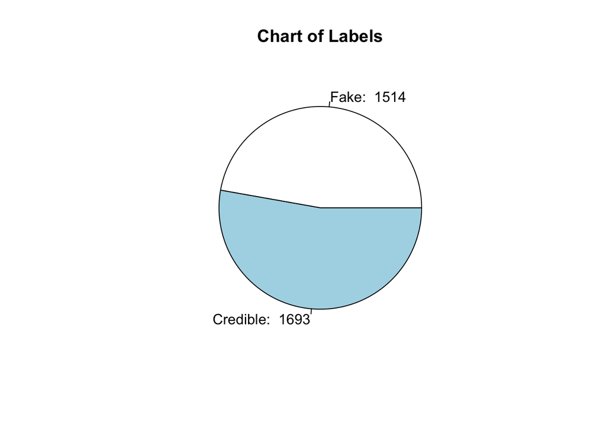

```r
viz_lables_before = function() {
  slices <- c(model$total_fake_class, model$total_credible_class) # total_fake_class, total_credible_class
  lbls <- paste(c("Fake: ", "Credible: "), slices)
  pie(slices, labels = lbls, main = "Chart of Labels")
}

viz_lables_before()
```

## Visualization of top words in fake news

This word cloud visualizes the words most frequently associated with “Fake” news.

```r
viz_fake_words = function() {
  wordcloud2(data = data.frame(word = names(model$fake_words), freq = unlist(model$fake_words)), color = "red")
}
viz_fake_words()
```

[interactive chart not shown]

## Visualization of top words in credible news

This word cloud visualizes the words most frequently associated with “Credible” news.

```r
viz_credible_words = function() {
  wordcloud2(data = data.frame(word = names(model$credible_words), freq = unlist(model$credible_words)), color = "green")
}

viz_credible_words()
```

[interactive chart not shown]

### This bar plot shows the number of credible messages predicted as credible in green and the number of credible messages predicted as fake in red.

```r
actual <- model$dataSetWithPrediction$Label
predicted <- model$dataSetWithPrediction$Prediction

cm <- confusionMatrix(as.factor(predicted), as.factor(actual), positive = lables[1])
print(cm)
```

```
## Confusion Matrix and Statistics
##
##           Reference
## Prediction credible fake
##   credible      438   23
##   fake            6  335
##
##                Accuracy : 0.9638
##                  95% CI : (0.9485, 0.9757)
##     No Information Rate : 0.5536
##     P-Value [Acc > NIR] : < 2.2e-16
##
##                   Kappa : 0.9265
##
##  Mcnemar's Test P-Value : 0.002967
##
##             Sensitivity : 0.9865
##             Specificity : 0.9358
##          Pos Pred Value : 0.9501
##          Neg Pred Value : 0.9824
##              Prevalence : 0.5536
##          Detection Rate : 0.5461
##    Detection Prevalence : 0.5748
##       Balanced Accuracy : 0.9611
##
##        'Positive' Class : credible
##
```

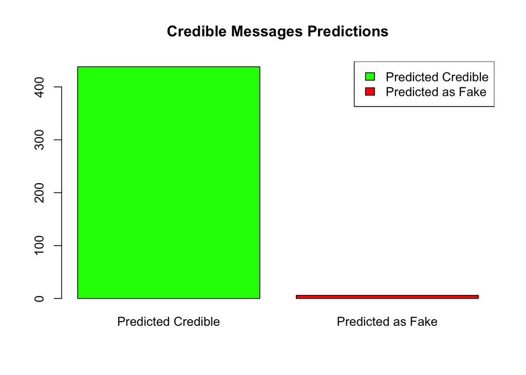

```r
actual_credible <- sum(actual == lables[1])
predicted_credible <- sum(predicted == lables[1] & actual == lables[1])
predicted_as_fake <- actual_credible - predicted_credible

values <- c(predicted_credible, predicted_as_fake)
labels <- c("Predicted Credible", "Predicted as Fake")

barplot(values, names.arg = labels, main = "Credible Messages Predictions", col = c("green", "red"), ylim = c(0, max(values) + 10))
legend("topright", c("Predicted Credible", "Predicted as Fake"), fill = c("green", "red"))
```

### This bar plot shows the number of fake messages predicted as fake in red and the number of fake messages predicted as credible in green

```r
actual <- model$dataSetWithPrediction$Label
predicted <- model$dataSetWithPrediction$Prediction

cm <- confusionMatrix(as.factor(predicted), as.factor(actual), positive = lables[2])
print(cm)
```

```
## Confusion Matrix and Statistics
##
##           Reference
## Prediction credible fake
##   credible      438   23
##   fake            6  335
##
##                Accuracy : 0.9638
##                  95% CI : (0.9485, 0.9757)
##     No Information Rate : 0.5536
##     P-Value [Acc > NIR] : < 2.2e-16
##
##                   Kappa : 0.9265
##
##  Mcnemar's Test P-Value : 0.002967
##
##             Sensitivity : 0.9358
##             Specificity : 0.9865
##          Pos Pred Value : 0.9824
##          Neg Pred Value : 0.9501
##              Prevalence : 0.4464
##          Detection Rate : 0.4177
##    Detection Prevalence : 0.4252
##       Balanced Accuracy : 0.9611
##
##        'Positive' Class : fake
##
```

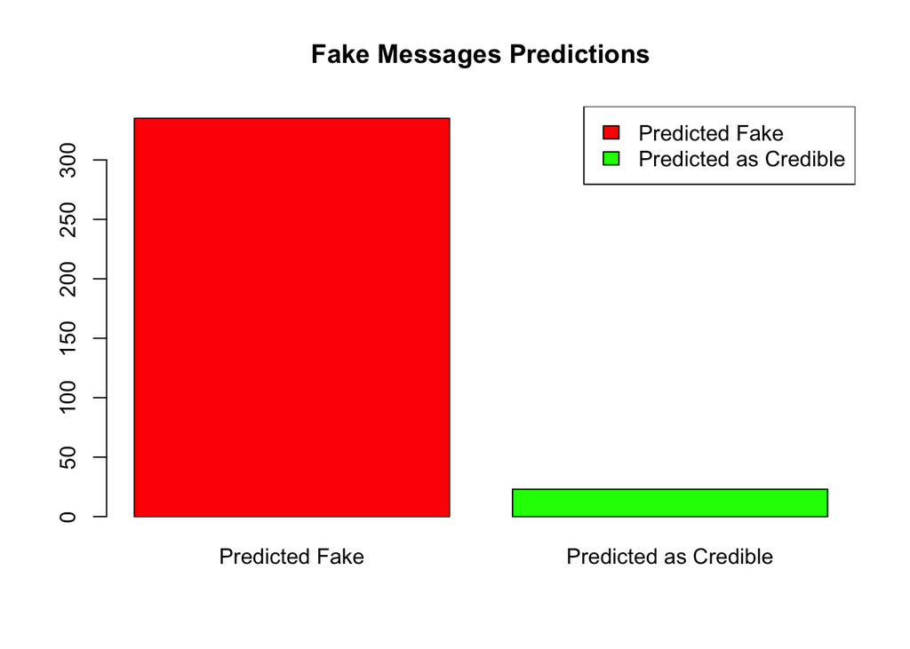

```r
actual_fake <- sum(actual == lables[2])
predicted_fake <- sum(predicted == lables[2] & actual == lables[2])
predicted_as_credible <- actual_fake - predicted_fake

values <- c(predicted_fake, predicted_as_credible)
labels <- c("Predicted Fake", "Predicted as Credible")

barplot(values, names.arg = labels, main = "Fake Messages Predictions", col = c("red", "green"), ylim = c(0, max(values) + 10))
legend("topright", c("Predicted Fake", "Predicted as Credible"), fill = c("red", "green"))
```

### ‘Chart of Prediction’ visualizes the distribution of news articles as predicted by the Naive Bayes classifier and ‘Chart of Labels’ visualizes the actual distribution

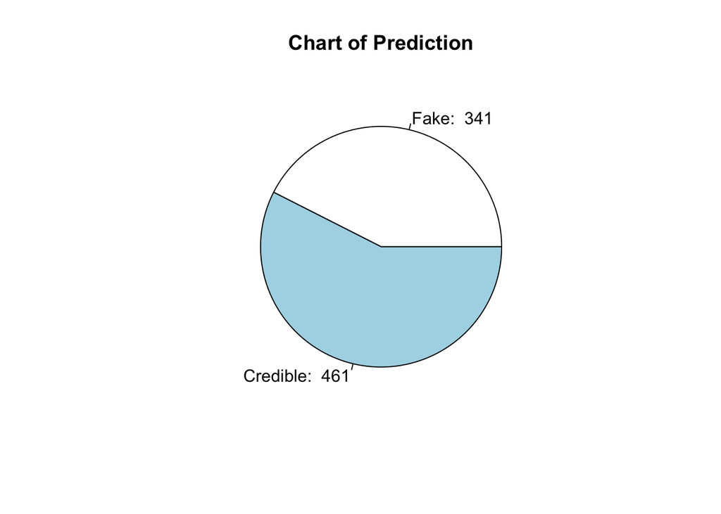

```r
viz_lables_after = function() {
  x <- 0
  y <- 0
  for(i in model$dataSetWithPrediction$Prediction){
    if (i == "credible"){
      x <- x +1
    } else{
      y <- y+1
    }
  }
  slices <- c(y, x) # total_fake_class, total_credible_class
  lbls <- paste(c("Fake: ", "Credible: "), slices)
  pie(slices, labels = lbls, main = "Chart of Prediction")
}

viz_lables_aftL = function() {
  x <- 0
  y <- 0
  for(i in model$dataSetWithPrediction$Label){
    if (i == "credible"){
      x <- x +1
    } else{
      y <- y+1
    }
  }
  slices <- c(y, x) # total_fake_class, total_credible_class
  lbls <- paste(c("Fake: ", "Credible: "), slices)
  pie(slices, labels = lbls, main = "Chart of Labels(true)")
}

viz_lables_after()
```

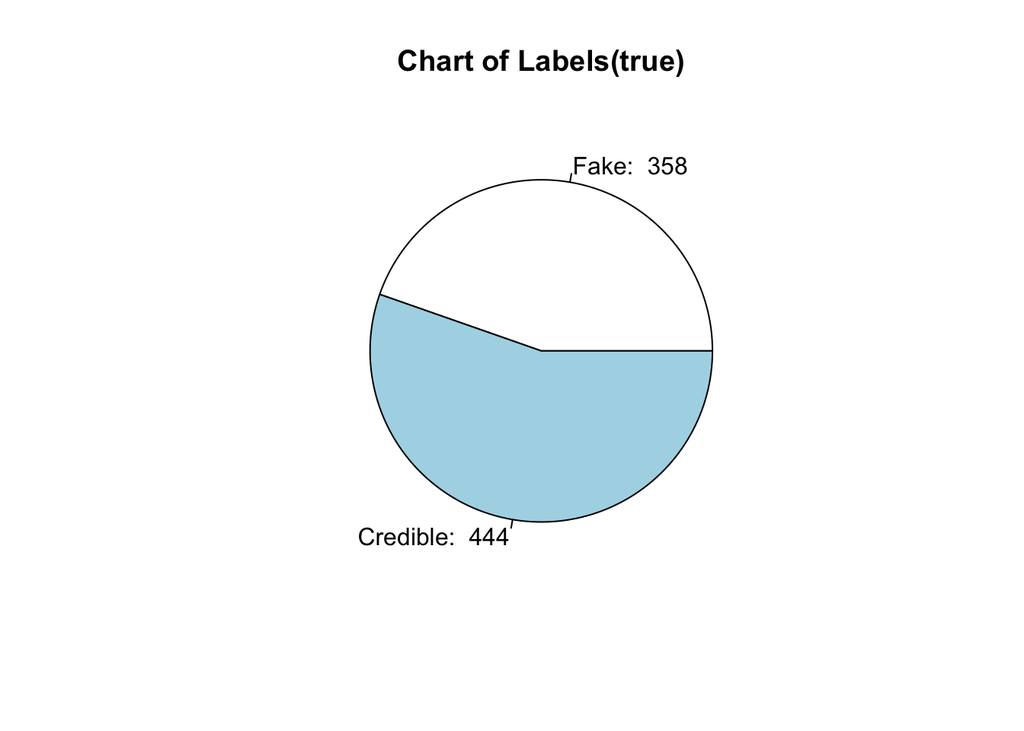

```r
viz_lables_aftL()
```

# Accuracy **estimation**

```r
score = function(){
    dataSetWithPrediction <<- createDataWithPredictions()
    actual <- dataSetWithPrediction$Label
    predicted <- dataSetWithPrediction$Prediction

    TP <- sum(actual == lables[1] & predicted == lables[1])
    FP <- sum(actual == lables[2] & predicted == lables[1])
    TN <- sum(actual == lables[2] & predicted == lables[2])
    FN <- sum(actual == lables[1] & predicted == lables[2])

    accuracy <<- (TP + TN) / (TP + FP + TN + FN)
    recall <<- TP / (TP + FN)
    precision <<- TP / (TP + FP)
    f1_score <<- 2 * (precision * recall) / (precision + recall)
  }
```

## Conclusions

#### Implementation method

At first we had to prepare our data. The data is cleaned by removing punctuation, numbers, and stop words. The result is saved in *cleaned.csv* and all further training we perform using this cleaned file.

Then we had to implement The Naive Bayes Classifier. At first we have to create bag-of-words in our *fit* function, we set all necessary attributes there. Then we have *predict* function, which calculates probability that word belongs to “fake” or “credible” class, calculate words frequencies in message and estimate it is “fake” or “credible” according to conditional probability. Last step is to score our results.

Also, visualization. They are provided to understand the data distribution, word frequencies, and predictions.

The model’s accuracy, sensitivity, and F1 score are calculated to assess its performance.

#### Pros&Cons

*Pros*

- The Naive Bayes Classifier is straightforward and easy to understand, making it suitable for text classification tasks.
- It can handle large datasets efficiently due to its simplicity.

*Cons*

- The method assumes that words are conditionally independent, which may not hold true in some real-world scenarios.
- Naive Bayes may not capture complex relationships between words and may not perform as well as more sophisticated models like deep learning approaches.